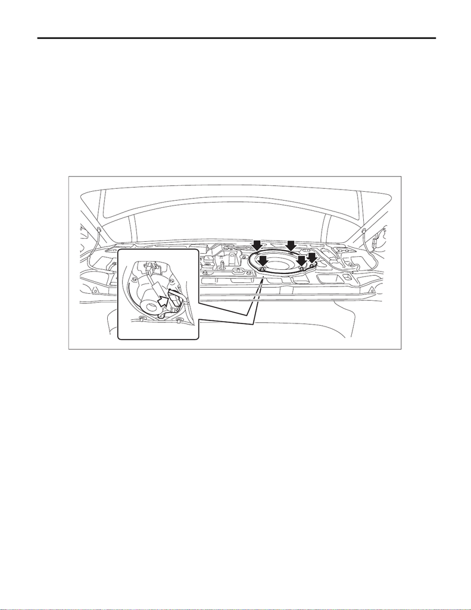

ET-12

Woofer

ENTERTAINMENT

8.Woofer

A: REMOVAL

1) Disconnect the ground cable from battery. <Ref. to NT-5, BATTERY, NOTE, Note.>

NOTE:

For models other than STI model, disconnect the ground terminal from battery sensor.

2) Remove the rear seat cushion assembly. <Ref. to SE-29, REMOVAL, Rear Seat.>

3) Remove the trim panel - rear pillar UPR and the trim panel - rear pillar LWR. <Ref. to EI-89, REMOVAL,

Rear Quarter Trim.>

4) Remove the trim panel assembly - rear shelf. <Ref. to EI-92, REMOVAL, Rear Shelf Trim.>

5) Remove the speaker assembly - woofer.

(1) Disconnect the connector.

(2) Remove the bolts and remove the speaker assembly - woofer.

B: INSTALLATION

1) Install the speaker assembly - woofer.

Tightening torque:

7.5 N·m (0.8 kgf-m, 5.5 ft-lb)

2) Install the trim panel assembly - rear shelf.

3) Install the trim panel - rear pillar UPR and the trim panel - rear pillar LWR.

4) Install the rear seat cushion assembly.

5) Connect the battery ground terminal. <Ref. to NT-5, BATTERY, NOTE, Note.>

NOTE:

For models other than STI model, connect the ground terminal to battery sensor.

ET-00909